# Peña_DSC550_Week2

#### DSC 550

#### Week 2 Exercise

#### 03/24/2024

**Using a data set of your choice, write an introduction explaining the data set.**

The dataset presented aims to determine any relationship that might exist between smoking and other factors such as gender and ethnicity. Its purpose is to analyze patterns between the variables aforementioned as well as others like age, marital status, education, and nationality to name a few.

**Identify a question or question(s) that you would like to explore in your data set.**

1) Does marital status affect whether or not a person smokes? 2) Are female individuals or male individuals more likely to be smokers? 3) How does age affect if an individual smokes or not?

**Create at least three graphs that help answer these questions. Make sure your graphs are clearly readable and are labeled appropriately and professionally.**

```python
# download necessary packages

import matplotlib.pyplot as plt
import numpy as np
import pandas as pd

import matplotlib as mpl
```

```python
# import the dataset

smoking = pd.read_csv('smoking.csv')
smoking
```

|  | Unnamed: 0 | gender | age | marital_status | highest_qualification | nationality | ethnicity | gross_income | region | smoke | amt_weekends | amt_weekdays | type |
| --- | --- | --- | --- | --- | --- | --- | --- | --- | --- | --- | --- | --- | --- |
| 0 | 1 | Male | 38 | Divorced | No Qualification | British | White | 2,600 to 5,200 | The North | No | NaN | NaN | NaN |
| 1 | 2 | Female | 42 | Single | No Qualification | British | White | Under 2,600 | The North | Yes | 12.0 | 12.0 | Packets |
| 2 | 3 | Male | 40 | Married | Degree | English | White | 28,600 to 36,400 | The North | No | NaN | NaN | NaN |
| 3 | 4 | Female | 40 | Married | Degree | English | White | 10,400 to 15,600 | The North | No | NaN | NaN | NaN |
| 4 | 5 | Female | 39 | Married | GCSE/O Level | British | White | 2,600 to 5,200 | The North | No | NaN | NaN | NaN |
| ... | ... | ... | ... | ... | ... | ... | ... | ... | ... | ... | ... | ... | ... |
| 1686 | 1687 | Male | 22 | Single | No Qualification | Scottish | White | 2,600 to 5,200 | Scotland | No | NaN | NaN | NaN |
| 1687 | 1688 | Female | 49 | Divorced | Other/Sub Degree | English | White | 2,600 to 5,200 | Scotland | Yes | 20.0 | 20.0 | Hand-Rolled |
| 1688 | 1689 | Male | 45 | Married | Other/Sub Degree | Scottish | White | 5,200 to 10,400 | Scotland | No | NaN | NaN | NaN |
| 1689 | 1690 | Female | 51 | Married | No Qualification | English | White | 2,600 to 5,200 | Scotland | Yes | 20.0 | 20.0 | Packets |
| 1690 | 1691 | Male | 31 | Married | Degree | Scottish | White | 10,400 to 15,600 | Scotland | No | NaN | NaN | NaN |

1691 rows × 13 columns

```python
# determine the number of smokers for each of the 5 marital statuses

smoker_marital_yes = smoking[smoking['smoke'] == 'Yes'].groupby('marital_status').size()
smoker_marital_yes
```

```
marital_status
Divorced      58
Married      143
Separated     22
Single       158
Widowed       40
dtype: int64
```

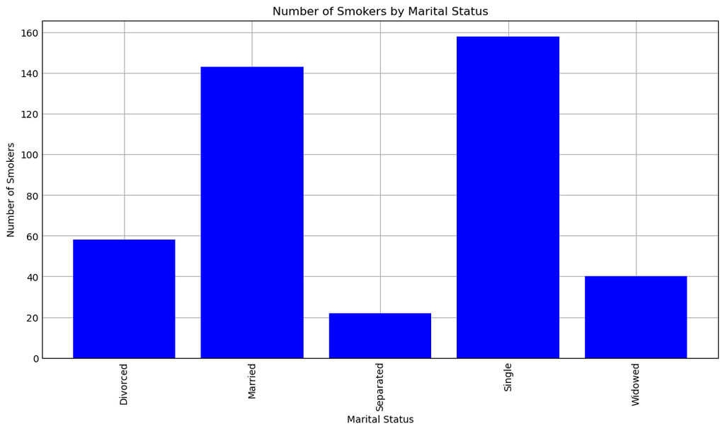

```python
plt.figure(figsize = (10, 5))
plt.bar(smoker_marital_yes.index, smoker_marital_yes.values, color = 'blue')
plt.xlabel('Marital Status')
plt.ylabel('Number of Smokers')
plt.title('Number of Smokers by Marital Status')
# rotate x-axis labels since they do not fill well horizontally
plt.xticks(smoker_marital_yes.index, rotation = 90)
plt.show()
```

```python
# determine the number of non-smokers for each of the 5 marital statuses

smoker_marital_no = smoking[smoking['smoke'] == 'No'].groupby('marital_status').size()
smoker_marital_no
```

```
marital_status
Divorced     103
Married      669
Separated     46
Single       269
Widowed      183
dtype: int64
```

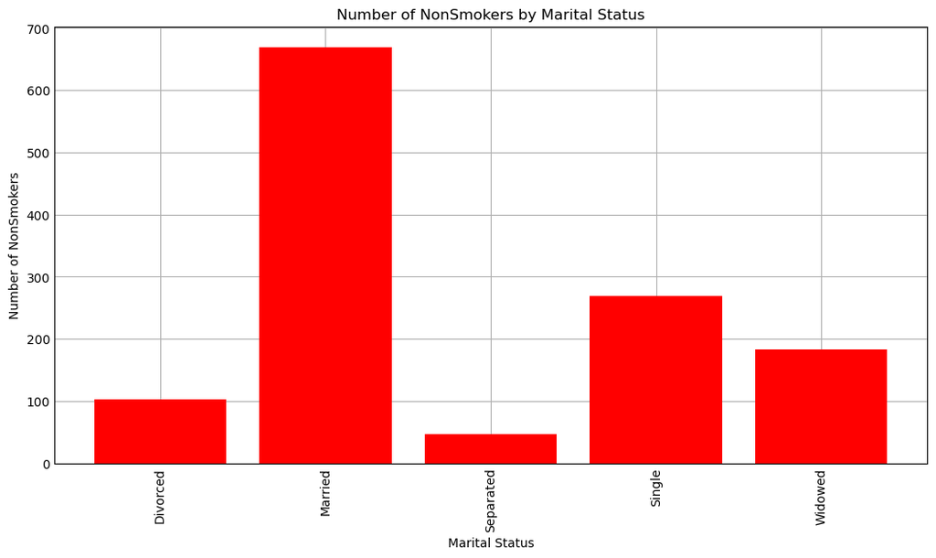

```python
plt.figure(figsize = (10, 5))
plt.bar(smoker_marital_no.index, smoker_marital_no.values, color = 'red')
plt.xlabel('Marital Status')
plt.ylabel('Number of NonSmokers')
plt.title('Number of NonSmokers by Marital Status')
# rotate x-axis labels since they do not fill well horizontally
plt.xticks(smoker_marital_no.index, rotation = 90)
plt.show()
```